# Introduction to Data Analysis and Visualization

Muhammad Hilmi Abdul Majid

## Introduction

Data analysis and visualization help us make sense of the vast amounts of information we collect daily. Whether in business, science, healthcare, or social media, data is everywhere. However, raw data by itself is difficult to interpret. This is where data analysis and visualization come in. By examining and presenting data in a clear and meaningful way, we can discover patterns, trends, and insights that would otherwise remain hidden.

## Importance of Data Analysis and Visualization

Data analysis is a powerful tool for making informed decisions. It enables businesses to understand customer behavior, helps scientists test hypotheses, and supports governments in developing effective policies. Without proper analysis, data remains just numbers and text, lacking meaningful insights.

Equally important is data visualization. A well-designed chart or graph can convey complex information quickly and effectively. Instead of sifting through pages of raw data, a single visualization can highlight trends, comparisons, and relationships at a glance, making it easier to interpret and act upon insights.

The importance of data analysis and visualization in today’s data-driven world cannot be overstated. Their value extends across several key areas:

- **Informed Decision-Making:** Data analysis turns raw information into actionable insights, enabling evidence-based decisions.
- **Problem-Solving:** Identifying patterns and underlying issues helps address complex challenges with practical solutions.
- **Identifying Opportunities:** Visualization reveals trends and potential opportunities, helping organizations stay ahead in emerging markets and evolving customer preferences.
- **Enhancing Communication:** Well-crafted visualizations make complex data accessible to both technical and non-technical audiences.
- **Driving Innovation:** Uncovering hidden patterns fosters new strategies, products, and services.
- **Ensuring Transparency:** Clear data presentations improve accountability and facilitate informed discussions among stakeholders.

By combining analysis with visualization, organizations can unlock the true potential of data, leading to smarter decisions, improved strategies, and meaningful progress.

## Tools for Data Analysis and Visualization

A variety of tools and technologies are available for data analysis and visualization. Popular options include:

- **R:** Renowned for its statistical analysis capabilities and visualization libraries like `ggplot2`.
- **Python:** Widely used for its versatile data manipulation libraries (`pandas`, `NumPy`) and visualization tools (`Matplotlib`, `Seaborn`, `Plotly`).
- **Tableau:** A user-friendly platform for creating interactive dashboards and visual analytics.
- **Microsoft Power BI:** Another platform for creating interactive reports and dashboard offered by Microsoft.
- **Microsoft Excel:** A ubiquitous tool for basic data analysis and visualization tasks.

For this course, we will be using R extensively. We will begin by introducing R and RStudio, and how to do basic calculations using it. Then we will discover basic functionalities in R including how to plot graphs and visual using base R. Afterwards, we will be using `ggplot2` library to produce multiple types of visuals.

## Principles of Data Visualization

Good data visualization follows several key principles to ensure clarity and accuracy. The goal is to present data in a way that is easy to understand, without distortion or misinterpretation. Some important principles include:

- **Simplicity**: Avoid unnecessary decorations and complexity. Focus on presenting the data clearly.
- **Accuracy**: Ensure the visualization accurately represents the data without misleading distortions.
- **Consistency**: Use the same scales, colors, and formats throughout your visualizations to make them easier to compare.
- **Efficiency**: Allow viewers to grasp key insights quickly. The best visualizations do not require much explanation.
- **Engagement**: A good visualization should capture attention and encourage exploration of the data.

Expanding on these principles, we can also consider aspects such as:

- **Accessibility**: Visualizations should be designed to be understood by a wide audience, including those with color blindness or other visual impairments.
- **Relevance**: Data should be displayed in a way that is pertinent to the objective at hand, avoiding extraneous details that may confuse the audience.
- **Comparability**: When presenting multiple datasets, ensure they can be easily compared by maintaining consistent units, scales, and visual styles.

## Components of Data Visualization

Visuals or graphs used to display data can be broken into several components including **visual cues**, **coordinates**, **scales**, and **context**. Each visualization is formed by a data and these four components, and the choice on how to use these components depends on the type of data and what you want to highlight.

### Visual cues to display data

First, we have the visual cues or geometries, which are fundamental elements that help in representing data graphically. These cues allow viewers to interpret the meaning of data effectively. The key visual cues used in data visualization include position, length, direction, angle, area, volume, and colors.

Note however that some visual cues are more readable than others. In particular, human eyes tend to read position and length much easier compared to area, volume, or colors.

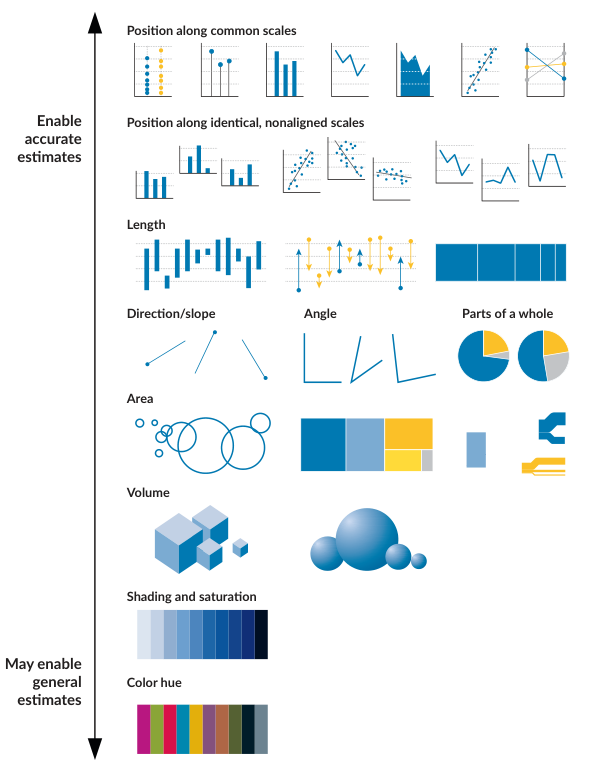

Perceptual ranking of visual cues or geometries that can be used to display data. Source: Better Data Visualizations by Jonathan Schwabish (2021)

- **Position:** Position is one of the most effective visual cues for displaying data. It allows users to interpret values based on their placement on a coordinate system. For example, in a scatter plot, the position of points along the x and y axes represents relationships between two variables. Proper alignment and spacing enhance readability and comprehension.
- **Length:** The length of graphical elements, such as bars in a bar chart or lines in a line chart, effectively represents quantitative differences. Since humans can easily compare lengths, this cue is particularly useful for visualizing ranked or sequential data.
- **Direction:** The direction of elements in visualizations can indicate trends and patterns. For instance, an upward-sloping line in a time-series chart signifies growth, while a downward slope suggests decline. The interpretation of direction helps in understanding overall data movement.
- **Angle:** Angle is commonly used in pie charts and radial diagrams to represent proportions. However, it is less effective than position or length for precise comparisons, as the human eye struggles to distinguish small variations in angles.
- **Area and volume:** The area of shapes, such as circles in a bubble chart or squares in a treemap, can be used to represent magnitudes. Larger areas indicate higher values, but it is essential to scale them correctly to avoid misinterpretation. Volume is an extension of area in three-dimensional visualizations, where size in all three dimensions conveys value. However, humans struggle to accurately compare volumes, making this cue less reliable for precise data representation.
- **Colors:** Colors help differentiate categories, indicate intensities, or highlight important data points. For instance, heatmaps use color gradients to represent variations in intensity, while categorical data can be distinguished using distinct hues. Choosing the right color scheme is crucial for accessibility and effective communication.

### Coordinates on canvas

The second component to data visualization is the coordinate systems used to draw the visual cues on the canvas. To accurately represent data visually, you need a coordinate system that provides a spatial reference. The three most common coordinate systems in data visualization are Cartesian, polar and geographical coordinates.

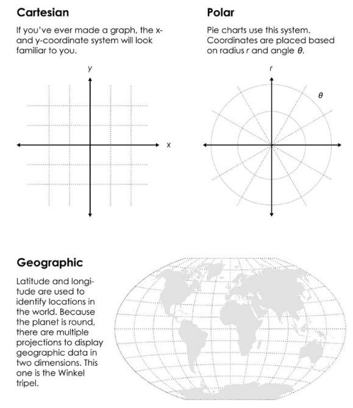

Different coordinate systems. Source: Data Points: Visualization That Means Something by Nathan Yau (2013)

- **Cartesian Coordinates:** This system is based on x and y axes (and sometimes a z-axis for 3D representations). It is commonly used in bar charts, scatter plots, and line graphs. The Cartesian coordinate system allows for precise placement of data points and is effective for depicting relationships between variables. In 3D visualizations, the addition of the z-axis enables multi-dimensional analysis, which can be useful in scientific and engineering applications.
- **Polar Coordinates:** The polar coordinates use an angular and radial reference, suitable for pie charts, radial charts, and circular histograms. In this system, data points are defined by an angle and a distance from a central point, making it useful for displaying cyclical data or proportions. Radial charts often help in understanding seasonal trends, wind directions, and frequency distributions where circular patterns are significant.
- **Geographical Coordinates:** The geographical coordinates are used in map-based visualizations, where latitude and longitude help plot locations on a map. These coordinates are essential in geospatial analysis, enabling visualization of demographic patterns, geographic distributions, and route optimizations. Combining geographical coordinates with color gradients or markers enhances insights into spatial data, such as population density or climate variations.

The use of coordinate systems depends on the type of data and visualization we plan to use. For example, if we have geospatial data where we want to display geographical information, we should opt for geographical coordinates. If we plan to display amounts as proportions in a pie or donut chart, we can use polar coordinates.

### Scales

The third component are scales. Scales define how data values map to visual elements, ensuring proportionality and accurate representation. There are different types of scales used in data visualization.

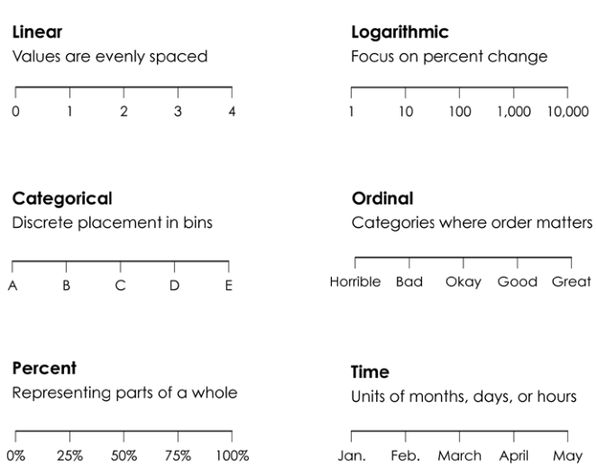

Scales. Source: Data Points: Visualization That Means Something by Nathan Yau (2013)

- **Linear scale**: Represents data using equal intervals, making it ideal for charts where consistent differences between values matter, such as bar charts, line charts, and scatter plots. It is useful when data changes at a steady rate.
- **Logarithmic scale**: Useful for data with large ranges, where each step represents a multiplicative factor rather than an additive one. This type of scale is effective for visualizing exponential growth, such as population growth, stock market prices, or seismic activity.
- **Categorical scale**: Used for non-numeric, discrete data where categories are distinct but do not have a specific order. This type of scale is commonly found in bar charts where different groups (such as countries, brands, or types of products) are represented without implying a hierarchy.
- **Ordinal scale**: Represents categorical data where order matters but distances between categories are not uniform. For example, survey responses like “poor,” “average,” “good,” and “excellent” have a ranking but do not have a defined numerical difference between them.
- **Percent scale**: This scale is used when data values represent proportions out of a whole (0-100%). Pie charts, stacked bar charts, and progress indicators often utilize percent scales to show relative contributions of different categories.
- **Temporal scale**: Used for time-series data, mapping values to dates or time units. This scale is essential in line graphs or time-based charts where changes over time need to be visualized, such as stock trends, temperature variations, or historical events.

In a visual, you may choose different scale for different axis. For example, in a bar chart for categorical variable, you may use the categorical scale for the x-axis, and numeric or linear scale for the y-axis. Choosing the appropriate scale is crucial for accurate and meaningful data interpretation.

### Context

Visual cues, coordinate systems, and scales are not enough to make up a visual to display data. The last component for data visualization is context, which is an often-overlooked but essential component of data visualization. Providing sufficient context ensures that the viewer correctly interprets the presented data. Important aspects of context include:

- **Titles and Labels**: Clearly describe what the visualization represents. Titles provide an overview of the chart’s purpose, while labels define axes, legends, and data points, ensuring clarity for the audience.
- **Legends**: Help decode colors, sizes, or shapes used in the visualization. Legends act as a key to understanding different categories, intensities, or groupings in a chart. Effective legends are concise, well-placed, and aligned with the overall design of the visualization.
- **Annotations**: Additional explanations or highlights to guide the viewer’s attention. These can include direct text labels, callouts, or dynamically generated tooltips that emphasize critical data points or trends.
- **Reference Lines and Gridlines**: Assist in reading values accurately by providing comparative references. Reference lines (such as average lines or trend lines) help contextualize data, while gridlines offer a structured way to measure values precisely without overwhelming the visual space.
- **Data Sources**: Indicating the source of data adds credibility and helps in validation. A well-documented source allows viewers to verify authenticity, trace methodologies, and assess the reliability of the data presented.

Note that not all of the list above is needed in a visual. The most important ones would be titles and labels. Without proper context, even the most well-designed visualizations can be misleading or difficult to interpret.

## Gestalt Principles in Data Visualization

Gestalt principles or theory are fundamental psychological concepts that explain how humans perceive visual elements as unified patterns rather than isolated components. These principles, initially introduced by Gestalt psychologists in the early 20th century, are crucial in data visualization as they influence how users interpret and derive meaning from graphical representations. There are six principles or laws described by Gestalt principles on how we perceive a visual that we will discuss here.

Unless specifically mentioned, images in this section are taken from Storytelling with Data: A Data Visualization Guide for Business Professionals by Cole Nussbaumer Knaflic (2015).

### 1. Proximity

Proximity refers to the tendency of humans to perceive elements that are close to each other as belonging to a group. In data visualization, proximity helps in grouping related data points together, making it easier to recognize patterns and relationships.

In the image below, due to the proximity between points, we perceive that there are three groups even though they are just points on a canvas.

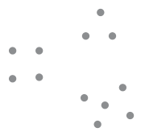

We see groups due to proximity between points

Similarly in the image below, we see points in columns (left) and in rows (right) due to the proximity between points.

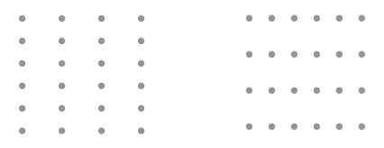

We see columns and rows due to proximity between points

### 2. Similarity

Similarity suggests that elements that share similar visual attributes (such as color, shape, or size) are perceived as related. This principle is essential in creating meaningful categorizations within data visualizations.

In the image below, we perceive the blue dots (left) are related or belong to a group. Similarly for the rectangles on the right.

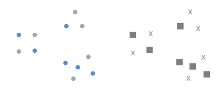

We think points are related by colors or shapes

### 3. Enclosure

Enclosure involves using visual boundaries, such as boxes or shading, to group related elements together. This principle strengthens the perception of unity among elements inside a boundary.

Using the image below as an example, the drawn rectangles form boundaries between points. We perceive points inside of the rectangles to be related and form a group.

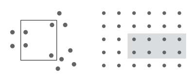

We think points are realted due to the boundaries

### 4. Closure

Closure occurs when the human eye tends to perceive incomplete shapes as complete, filling in gaps to create a whole image. This principle enhances visual storytelling by implying connections without explicitly drawing them.

In the image below, even though in reality, it is an image of disjointed lines with gaps, we perceive it as a circle by filling the gaps in our mind.

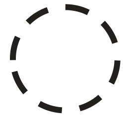

We see a circle, not disjointed segments

Similarly for the image below. There is a huge gap between the two lines (left). We may fill-in the gap by the yellow line on the right, although that may not be correct in reality.

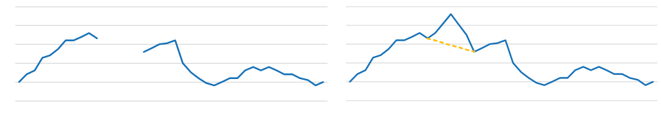

We mentally connect the gap. Source: Better Data Visualizations by Jonathan Schwabish (2021)

### 5. Continuity

Continuity is similar to closure. It describes the human tendency to perceive elements which are aligned with each other as having continuous forms rather than being disconnected.

Suppose we have elements such as (1) in the image below. If we pull the rectangles apart, most would perceive it as (2), instead of (3). Although it can either be both.

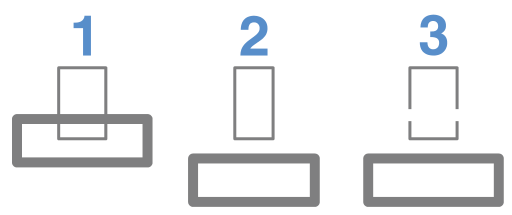

We see (2) as the continuity of (1), not (3)

### 6. Connection

Connection is the principle that elements connected by lines or other linking features are perceived as related. This is particularly useful in illustrating relationships between data points.

In the image below, the connecting lines cause us to perceive the connected points as related and form a group, whereas points not connected to the line are unrelated.

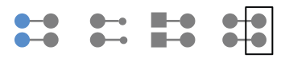

We see elements are related due to connecting lines

Looking at the image below, the scatterplot (left) does not imply any relationship between the points on the graph. But when lines are added (right), we see that they are connected and related.

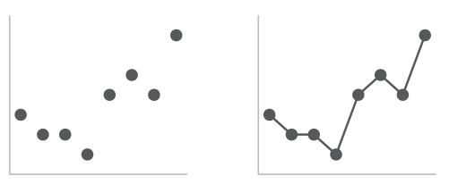

We see points are related due to connecting lines

## Conclusion

In this topic, we have briefly touched about the importance of data analysis and visualization. We have also introduced some concepts in the principles of data visualization. While these are used extensively when we produce visuals and graphs, we may not think of them explicitly. In the next topic, we will start introducing R and RStudio, which are used for data analysis and visualization by experts around the world.